# 36-315 Homework 10, Spring 2018

Anthony Chan(alc1), Minwhan cho(minwhanc), Zhichuan Duan(zhichuad), Devansh Kukreja(dkukreja)

Due Wednesday, April 18, 2018 (11:59pm) on Canvas

# Homework 10: An Interesting Duo - Networks and Time Series

*General instructions for all assignments*:

- Use this file as the template for your submission.
- Upload your edited `R` Markdown file **and** the knitted .html file, to the Homework 10 submission section on Canvas. (If you cannot upload 2 files at once to Canvas in Chrome, try another browser such as Firefox.). You want to name the .Rmd with all the Andrew IDs of the groups in the filename - e.g. [AndrewID1]-[AndrewID2]-[AndrewID3]-[AndrewID4]-Homework10.Rmd if the group was made of four members. **If you do not include both the .Rmd and .html files, you will automatically lose 10 points.**
- The instructor and TAs will run your .Rmd file on their computers. **If your .Rmd file does not knit on our computers, you will automatically lose 10 points.**
- Your file should contain the code to answer each question in its own code block. Your code should produce plots/output that will be automatically embedded in the output (.html) file
- Each answer must be supported by written statements (unless otherwise specified)
- Include the full names and Andrew IDs of the members of your group in Problem 0.
- Include names of classmates with whom you have collaborated in Problem 0 - outside the ones from your group.
- Include the style guide you used in Problem 0. **If you do not include and follow a style guide, you will automatically lose 10 points.**

# Problem 0

- “We used Hadley Wickham’s R style guide.”

*Keep just those that apply, and fill in details as needed:*

- “This submission is for the following group: Anthony Chan(alc1), Minwhan cho(minwhanc), Zhichuan Duan(zhichuad), Devansh Kukreja(dkukreja)

# Problem 1

(40 points)

**Undirected Network of *Love Actually* Characters**

1. *(0 points) Read [this article from FiveThirtyEight](https://fivethirtyeight.com/features/the-definitive-analysis-of-love-actually-the-greatest-christmas-movie-of-our-time/).*
2. *(5 points) Load the *Love Actually* adjacency matrix from [FiveThirtyEight’s GitHub Page](https://raw.githubusercontent.com/fivethirtyeight/data/master/love-actually/love_actually_adjacencies.csv). We store this in an object called `love_adjacency`, using the code below.*

```r
library(tidyverse)
love_adjacency <- read_csv("https://raw.githubusercontent.com/fivethirtyeight/data/master/love-actually/love_actually_adjacencies.csv")
```

3. *(5 points) Read about the `ggraph` package [here](http://www.data-imaginist.com/2017/Announcing-ggraph/). What does it do? What `ggplot()`-like function can you use with `ggraph`?*

ggraph() functions similarly to ggplot() in initializing a plot

4. *(15 points) Create a basic network diagram of the *Love Actually* data using the `ggraph` package and looking at the code in the article posted in part (c) above. Below we define the vector of actor names, `actor_names`, and the graph object, `LA_graph`. Take into consideration the following for building the visualization:*
- *The `LA_graph` object needs to be used in the `ggraph()` function*
- *Use the `'kk'` layout in `ggraph()` (which uses the spring-based algorithm by Kamada and Kawai to place nodes)*
- *The edges can be added with `geom_edge_label()`*
- *The actor names will be used as an aesthetic to label the nodes using the `geom_node_label()` function*
- *If the actor names are too big, you can format them using the `size` argument in `geom_node_label()`*
- *Remove tick marks for both the x and y axis*

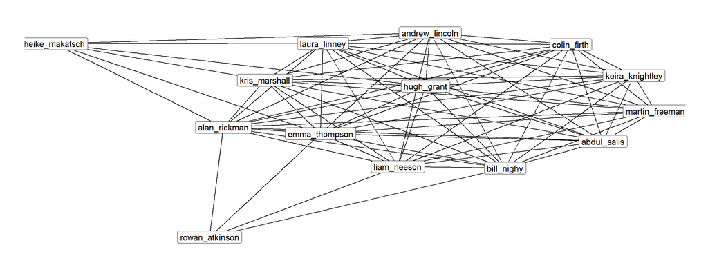

```r
#install.packages('igraph')
#install.packages('ggraph')
library(igraph)
library(ggraph)

actor_names <- love_adjacency[,1]
LA_graph <- graph_from_adjacency_matrix(as.dist(love_adjacency[,-1]))

ggraph(LA_graph, layout = 'kk') +
  geom_edge_link() +
  geom_node_label(aes(label = actor_names), size = 4) +
  theme_graph()
```

5. *(15 points) Repeat part (d), but now:*
- *Use a weighted graph, where the width of each edge shows the number of scenes in which those characters appear together. The code below will transform the adjacency matrix into a weighted graph structure, containing a `weight` variable. You should map the `weight` variable to the `edge_width` aesthetic inside `geom_edge_label()`.*
- *Change the `range` argument of `scale_edge_width()` so that the thinnest edges have width 0.5 and the thickest have width 3.*
- *Use another layout of your choice. See the help file for `layout_igraph_auto` which lists other layout options besides `kk`.*

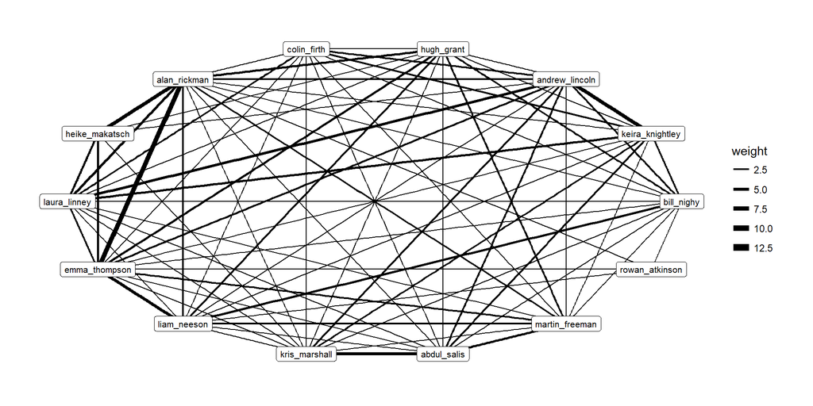

```r
LA_graph_weighted <- graph_from_adjacency_matrix(as.matrix(love_adjacency[,-1]),
                                        weighted = TRUE)

ggraph(LA_graph_weighted, layout = 'circle') +
  geom_edge_link(aes(edge_width = weight)) +
  geom_node_label(aes(label = actor_names), size = 2.8) +
  scale_edge_width(range = c(0.5,3)) +
  theme_graph()
```

# Problem 2

(40 points)

**Time Series and Dates in `ggplot()`**

Note: Almost all code for this problem is given to you already. Please take time to understand what the code does!

1. *(5 points) In this problem, we’ll be using data from the NYC Citi Bike program. The NYC Citi Bike data is a tremendous resource. We highly encourage you to explore the data on your own. The large version of this dataset is at the following link: [https://raw.githubusercontent.com/mateyneykov/315_code_data/master/data/big_bike.csv]*

*However, because this dataset is so large, we focus on only a small subset from June 2016 for this assignment, to ensure no one has issues accessing and/or loading in the original raw data files. Additional information about the NYC Citi Bike data can be found [here](https://www.citibikenyc.com/system-data).*

*Create a new variable, `start_date`, by transforming `starttime` with the following code:*

```r
library(tidyverse)

# Only use the June 2016 subset
bike <- read_csv("https://github.com/mateyneykov/315_code_data/raw/master/data/nyc-citi-bike-data-subset.csv")
#  Add start_date variable
bike <- mutate(bike,
               start_date = as.Date(starttime, format = "%m/%d/%Y"))
```

```r
min(bike$start_date)
```

```
## [1] "2016-06-01"
```

```r
max(bike$start_date)
```

```
## [1] "2016-06-30"
```

- *How many rows and columns are in the result?*
- *What are the minimum and maximum bike trip dates?*

bike has 4359 rows and 17 columns.

The earliest bike trip was June 1st and the latest was June 30th

2. *(15 points). Let’s plot the number of trips over time. First, we need to calculate the number of trips on any given day. This is easy with the `dplyr` package. Using the code below, we now have a new data frame (called `trips_per_day`). We can use it to create a nice time series plot with `ggplot()`, `geom_line()`, and `scale_x_date()` to properly format the x-axis:*

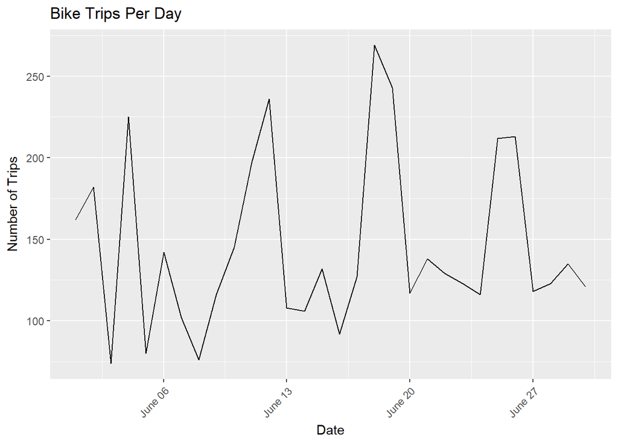

```r
#  Summarize bike, creating a new data.frame that includes the number
#  of trips taken on each day

trips_per_day <- bike %>%
  group_by(start_date) %>%
  summarize(n_trips = n())

#  Create a time series plot with the dates on the x-axis and the number of
#  trips per day on the y-axis

ggplot(trips_per_day, aes(x = start_date, y = n_trips)) +
  geom_line() +
  scale_x_date(date_breaks = "1 week", date_labels = "%B %d") +
  theme(axis.text.x = element_text(angle = 45, hjust = 1)) +
  labs(
    title = "Bike Trips Per Day",
    x = "Date",
    y = "Number of Trips"
  )
```

*Add the following to the plot above:*

- *Add an appropriate title*
- *Add appropriate axis labels*
- *Use `scale_x_date()` to format the x-axis ticks such that they appear **once a week** and show the **month and day**. For instance: “June 06”, “June 13”, etc. (Hint: look at the Lecture 19 notes and check the documentation for `strptime` on how to format dates in R.)*
- *Tilt the x ticks marks by 45 degrees for better legibility. (Hint: look again at the Lecture 19 notes on how `element_text` was used in the `theme` function.)*
3. *(5 points) Repeat part (b), but this time, split the time series into subscribers and customers in the `usertype` variable, and color by the `usertype` variable. As usual, we set the color aesthetics to map to the `usertype` variable to achieve this.*

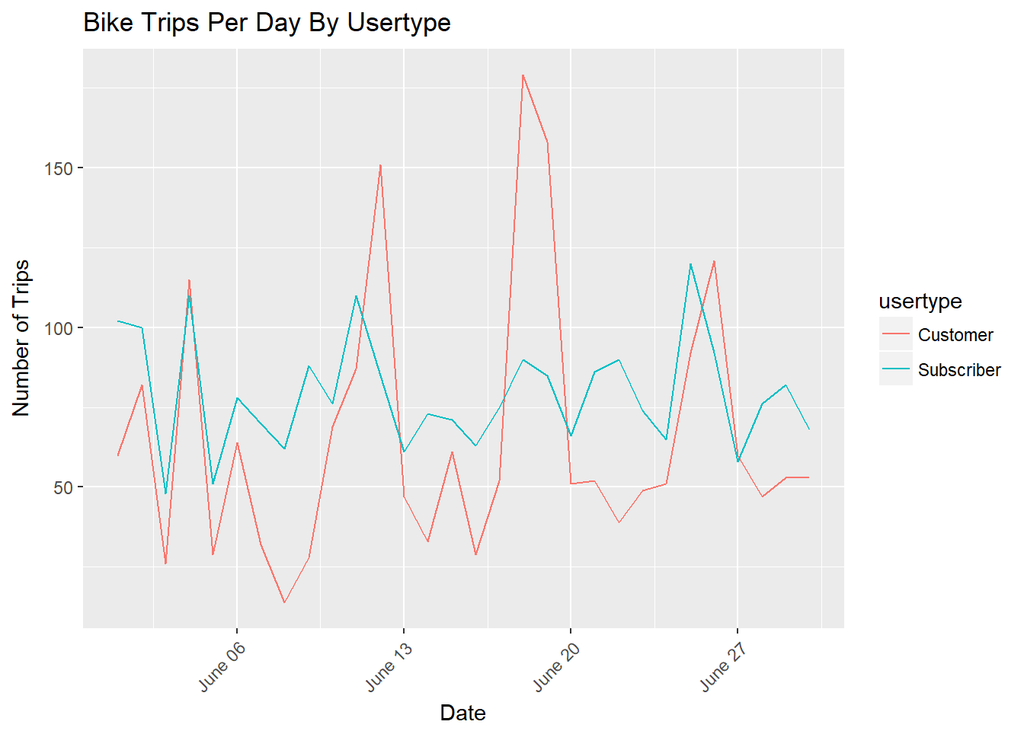

```r
#  Summarize bike, creating a new data.frame that includes the number
#  of trips taken on each day, split by usertype
trips_per_day_usertype <- bike %>%
  group_by(start_date, usertype) %>%
  summarize(n_trips = n())

#  Create a time series plot with the dates on the x-axis and the number of
#  trips per day on the y-axis, split by usertype

ggplot(trips_per_day_usertype, aes(x = start_date, y = n_trips, color = usertype)) +
  geom_line() +
  scale_x_date(date_breaks = "1 week", date_labels = "%B %d") +
  theme(axis.text.x = element_text(angle = 45, hjust = 1)) +
  labs(
    title = "Bike Trips Per Day By Usertype",
    x = "Date",
    y = "Number of Trips"
  )
```

*Again, as in part (b), add the following to the plot above:*

- *Add an appropriate title*
- *Add appropriate axis labels*
- *Use `scale_x_date()` to format the x-axis ticks to appear once a week, showing the month and day*
- *Tilt the x ticks marks by 45 degrees for better legibility*

*Which time series appears to have more fluctuation / variability? The customers or the subscribers? Does this make sense, considering that “subscribers” are annual members while “customers” are those who just bought a 24-hour or 3-day pass?*

It appears that customers have more fluctuation which makes sense since customers tend to use bikes in response to events/circumstances rather than on some sort of schedule.

4. *(15 points) As you have seen in class, the function `stat_rollapplyr()` of the package `ggseas` can compute moving average trend lines for a time series.*

*Following the Lecture 19 notes, give arguments to `stat_rollapplyr()` to compute a moving average with a 7-day window, right-aligned. Also make the moving-average trend lines thicker than the underlying data trend lines.*

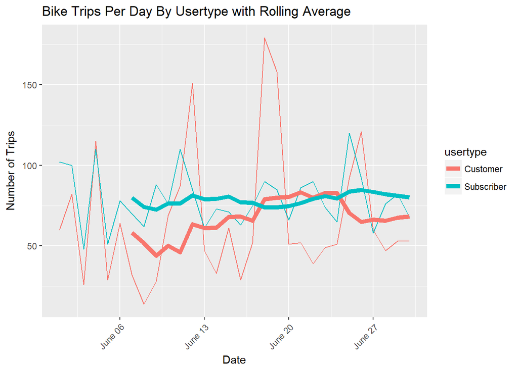

```r
#install.packages('ggseas')
library(ggseas)

ggplot(trips_per_day_usertype, aes(x = start_date, y = n_trips, color = usertype)) +
  geom_line() +
  stat_rollapplyr(width = 7, align = "right", size = 2) +
  scale_x_date(date_breaks = "1 week", date_labels = "%B %d") +
  theme(axis.text.x = element_text(angle = 45, hjust = 1)) +
  labs(
    title = "Bike Trips Per Day By Usertype with Rolling Average",
    x = "Date",
    y = "Number of Trips"
  )
```

*Again, as in parts (b-c), add the following to the plot above:*

- *Add an appropriate title*
- *Add appropriate axis labels*
- *Use `scale_x_date()` to format the x-axis ticks to appear once a week, showing the month and day*
- *Tilt the x ticks marks by 45 degrees for better legibility*

*Which time series’ **moving average** appears to have more fluctuation / variability?*

The customer moving average appears to have more fluctuation.